# Project3

Tian Ren

4/30/2018

## Part 1: Regression analysis of Gapminder data

**Exercise 1:** *Make a scatter plot of life expectancy across time.*

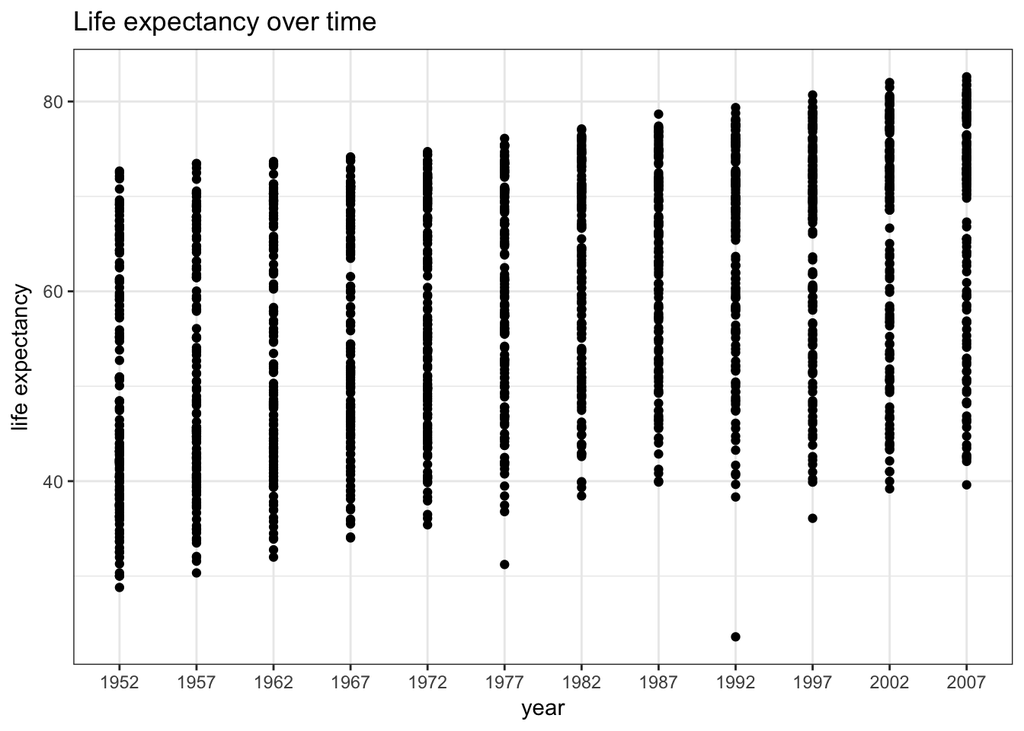

```r
gapminder %>%
  ggplot(aes(x=factor(year), y=lifeExp)) +
  geom_point() +
  labs(title="Life expectancy over time",
         x = "year",
         y = "life expectancy")
```

**Question 1:** *Is there a general trend (e.g., increasing or decreasing) for life expectancy across time? Is this trend linear?*

There is a generally increasing trend for life expectancy across time and it appears to follow a straight line so it may be linear.

A slightly different way of making the same plot is looking at the distribution of life expectancy across countries as it changes over time:

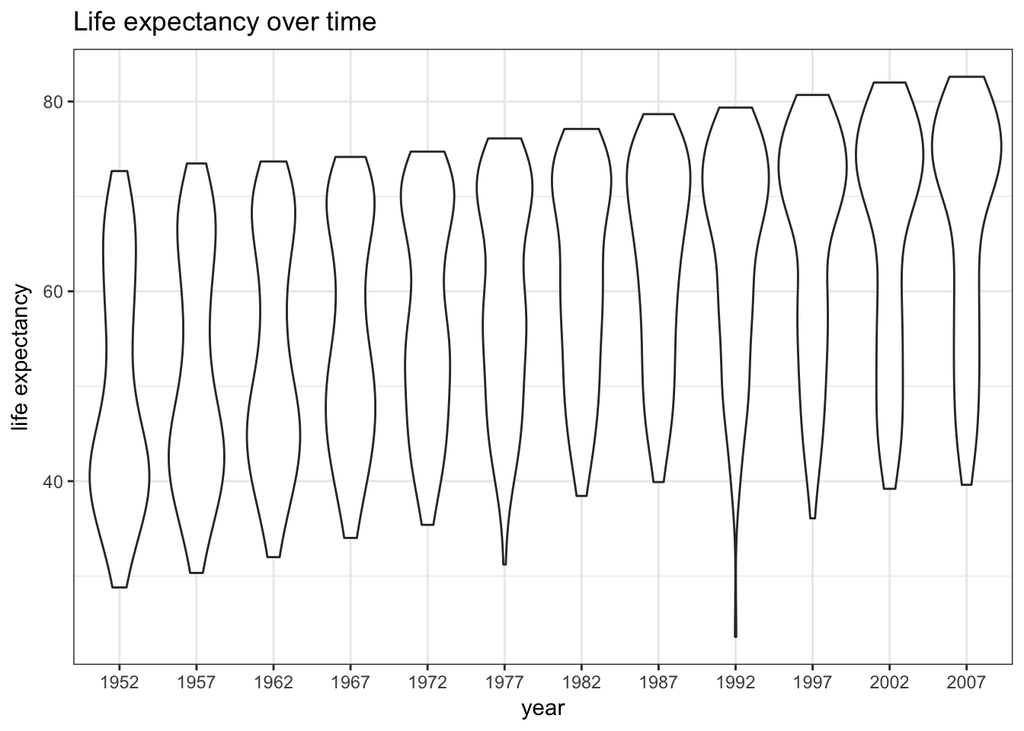

```r
gapminder %>%
  ggplot(aes(x=factor(year), y=lifeExp)) +
    geom_violin() +
    labs(title="Life expectancy over time",
         x = "year",
         y = "life expectancy")
```

**Question 2:** *How would you describe the distribution of life expectancy across countries for individual years? Is it skewed, or not? Unimodal or not? Symmetric around its center?*

The peak of life expectancy goes from bottom to top across time. In 1952, the peak shows at the bottom. As time goes on, the peak gets closer to the top. By 2007, the data is mostly concentrated around the top. Also, while the spread span stays roughly the same, the distribution is moving to higher figures. The general shape of the distribution (skinny on one end and wide in the other) indicates the distribution of life expectancy is skewed. The distribution appears to be multimodal before 1977 and unimodal after. None of the violins looks symmetric hence the distribution is not symmetric around the center.

**Question 3:** *Suppose I fit a linear regression model of life expectancy vs. year (treating it as a continuous variable), and test for a relationship between year and life expectancy, will you reject the null hypothesis of no relationship? (do this without fitting the model yet. I am testing your intuition.)*

It looks like there exists a linear relationship between year and life expectancy. So I would reject the null hypothesis of no relationship.

**Question 4:** *What would a violin plot of residuals from the linear model in Question 3 vs. year look like? (Again, don’t do the analysis yet, answer this intuitively)*

I would also expect the residual graph to follow a linear pattern since I believe there exists a linear relationship between year and life expectancy.

**Question 5:** *According to the assumptions of the linear regression model, what should that violin plot look like?*

The violins should look roughly symmetrical with one peak in the middle and very similar to one another in shape and size. Their peaks are generally around 0. Also, they should roughly follow a linear pattern.

**Exercise 2:** *Fit a linear regression model using the lm function for life expectancy vs. year (as a continuous variable). Use the broom::tidy to look at the resulting model.*

```r
fit <- lm(lifeExp~year, data = gapminder)
fit_stats <- fit %>%
  broom::tidy()
fit_stats
```

```
##          term     estimate   std.error statistic      p.value
## 1 (Intercept) -585.6521874 32.31396452 -18.12381 2.897807e-67
## 2        year    0.3259038  0.01632369  19.96509 7.546795e-80
```

**Question 6:** *On average, by how much does life expectancy increase every year around the world?*

On average, life expectancy increases by 0.33 year every year around the world.

**Question 7:** *Do you reject the null hypothesis of no relationship between year and life expectancy? Why?*

We reject the null hypothesis because the p-value (7.546795e-80) is essentially zero (<0.05).

**Exercise 3:** *Make a violin plot of residuals vs. year for the linear model from Exercise 2 (use the broom::augment function).*

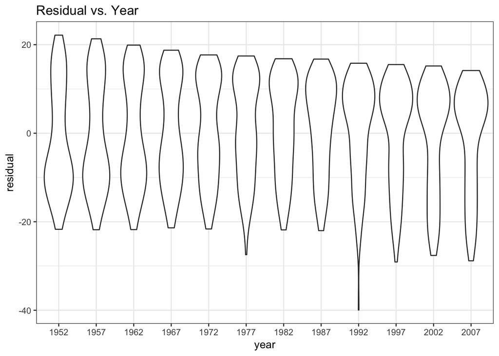

```r
fit %>%
  augment(data=gapminder) %>%
  ggplot(aes(x=factor(year), y=.resid)) +
  geom_violin() +
  labs(title="Residual vs. Year",
         x = "year",
         y = "residual")
```

**Question 8:** *Does the plot of Exercise 3 match your expectations (as you answered Question 4)?*

Yes. The pattern does look linear.

**Exercise 4:** *Make a boxplot (or violin plot) of model residuals vs. continent.*

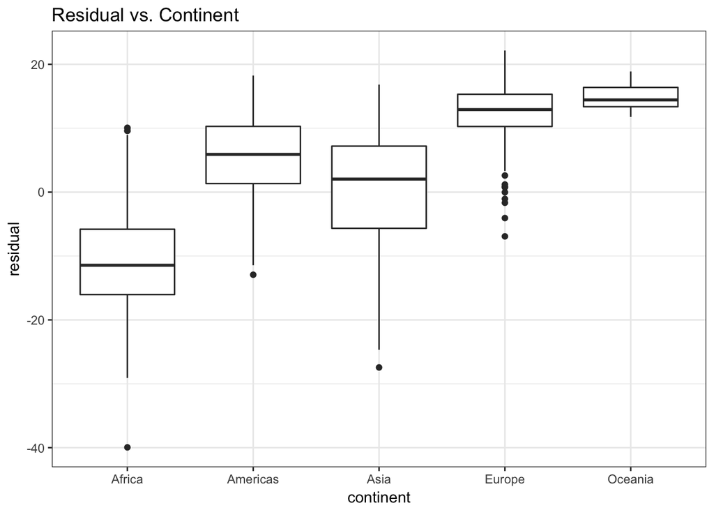

```r
fit %>%
  augment(data=gapminder) %>%
  ggplot(aes(x=continent, y=.resid)) +
  geom_boxplot() +
  labs(title="Residual vs. Continent",
       x = "continent",
       y = "residual")
```

**Question 9:** *Is there a dependence between model residual and continent? If so, what would that suggest when performing a regression analysis of life expectancy across time?*

In our boxplot above, we can see that the distribution of model residual (mean and variance) varies from continent to continent, which suggests a dependency between model residual and continent. This indicates that our model perhaps did not capture all the variables that would affect life expectancy.

**Exercise 5:** *Use `geom_smooth(method=lm)` in ggplot as part of a scatter plot of life expectancy vs. year, grouped by continent (e.g., using the color aesthetic mapping).*

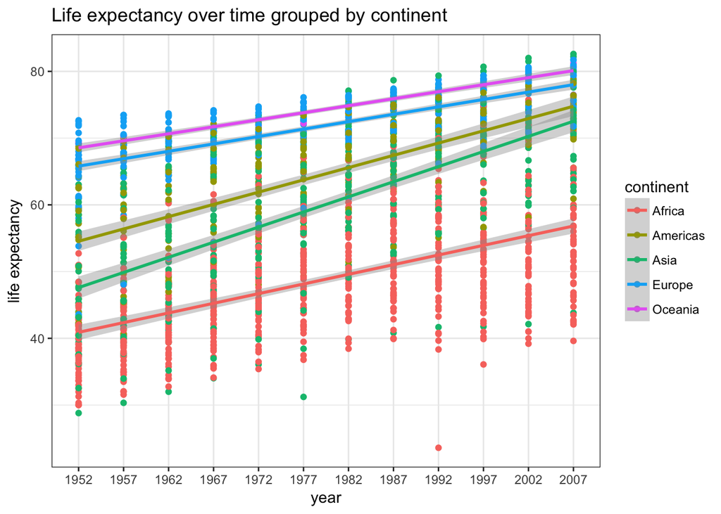

```r
gapminder %>%
  ggplot(aes(x=factor(year), y=lifeExp, group=continent, color=continent)) +
  geom_point() +
  geom_smooth(method=lm) +
  labs(title="Life expectancy over time grouped by continent",
         x = "year",
         y = "life expectancy")
```

**Question 10:** *Based on this plot, should your regression model include an interaction term for continent and year? Why?*

In the plot above, the fitted linear models vary from continent to continent (not parallel). Hence, the regression model should include an interaction term for continent and year.

**Exercise 6:** *Fit a linear regression model for life expectancy including a term for an interaction between continent and year. Use the broom::tidy function to show the resulting model.*

```r
multi_fit <- lm(lifeExp~year*continent, data=gapminder)
multi_fit_stats <- multi_fit %>%
  tidy()
multi_fit_stats
```

```
##                      term      estimate    std.error   statistic
## 1             (Intercept) -524.25784607  32.96342596 -15.9042281
## 2                    year    0.28952926   0.01665177  17.3872996
## 3       continentAmericas -138.84844718  57.85057778  -2.4001220
## 4           continentAsia -312.63304922  52.90355242  -5.9094907
## 5         continentEurope  156.84685210  54.49775866   2.8780423
## 6        continentOceania  182.34988290 171.28298566   1.0646118
## 7  year:continentAmericas    0.07812167   0.02922373   2.6732271
## 8      year:continentAsia    0.16359314   0.02672470   6.1214213
## 9    year:continentEurope   -0.06759712   0.02753003  -2.4553961
## 10  year:continentOceania   -0.07925689   0.08652512  -0.9159986
##         p.value
## 1  3.436134e-53
## 2  1.953998e-62
## 3  1.649695e-02
## 4  4.139916e-09
## 5  4.051687e-03
## 6  2.872034e-01
## 7  7.584665e-03
## 8  1.149941e-09
## 9  1.417280e-02
## 10 3.597980e-01
```

**Question 11:** *Are all parameters in the model significantly different from zero? If not, which are not significantly different from zero?*

Not all parameters in the model are significantly different from zero, such as continentOceania (p-value 0.29>0.05) and year:continentOceania (p-value 0.36>0.05).

**Question 12:** *On average, by how much does life expectancy increase each year for each continent? (Provide code to answer this question by extracting relevant estimates from model fit)*

```r
multi_fit_stats
```

```
##                      term      estimate    std.error   statistic
## 1             (Intercept) -524.25784607  32.96342596 -15.9042281
## 2                    year    0.28952926   0.01665177  17.3872996
## 3       continentAmericas -138.84844718  57.85057778  -2.4001220
## 4           continentAsia -312.63304922  52.90355242  -5.9094907
## 5         continentEurope  156.84685210  54.49775866   2.8780423
## 6        continentOceania  182.34988290 171.28298566   1.0646118
## 7  year:continentAmericas    0.07812167   0.02922373   2.6732271
## 8      year:continentAsia    0.16359314   0.02672470   6.1214213
## 9    year:continentEurope   -0.06759712   0.02753003  -2.4553961
## 10  year:continentOceania   -0.07925689   0.08652512  -0.9159986
##         p.value
## 1  3.436134e-53
## 2  1.953998e-62
## 3  1.649695e-02
## 4  4.139916e-09
## 5  4.051687e-03
## 6  2.872034e-01
## 7  7.584665e-03
## 8  1.149941e-09
## 9  1.417280e-02
## 10 3.597980e-01
```

We can tell from the model that, on average, life expectancy increases by 0.29 each year for Africa, 0.37 (0.28952926 + 0.07812167) for Americas, 0.45 (0.28952926 + 0.16359314) for Asia, 0.22 (0.28952926 - 0.06759712) for Europe and 0.21 (0.28952926 - 0.07925689) for Oceania.

**Exercise 7:** *Use the anova function to perform an F-test that compares how well two models fit your data: (a) the linear regression models from Exercise 2 (only including year as a covariate) and (b) Exercise 6 (including interaction between year and continent).*

We use the anova() function, which performs an F-test in order to test the null hypothesis that a model M1 is sufficient to explain the data against the alternative hypothesis that a more complex model M2 is required.

```r
anova(fit ,multi_fit)
```

```
## Analysis of Variance Table
##
## Model 1: lifeExp ~ year
## Model 2: lifeExp ~ year * continent
##   Res.Df    RSS Df Sum of Sq      F    Pr(>F)
## 1   1702 230229
## 2   1694  87320  8    142909 346.55 < 2.2e-16 ***
## ---
## Signif. codes:  0 '***' 0.001 '**' 0.01 '*' 0.05 '.' 0.1 ' ' 1
```

**Question 13:** *Is the interaction model significantly better than the year-only model? Why?*

The p-value comparing the year-only model to the interaction model is essentially zero ($<10^{-15}$), indicating that the first model is not sufficient. Also, there is a big drop in RSS (230229 to 87320). Hence the interaction model is significantly better than the year-only model.

**Exercise 8:** *Make a residuals vs. year violin plot for the interaction model. Comment on how well it matches assumptions of the linear regression model. Do the same for a residuals vs. fitted values model. (You should use the broom::augment function).*

This residuals vs. year violin plot shows that (1) they’re pretty symmetrically distributed, tending to cluster towards the middle of the plot; (2) they’re clustered around 0 of the y-axis; (3) in general there aren’t clear patterns. All of these qualities suggest that the interaction model performs reasonably well.

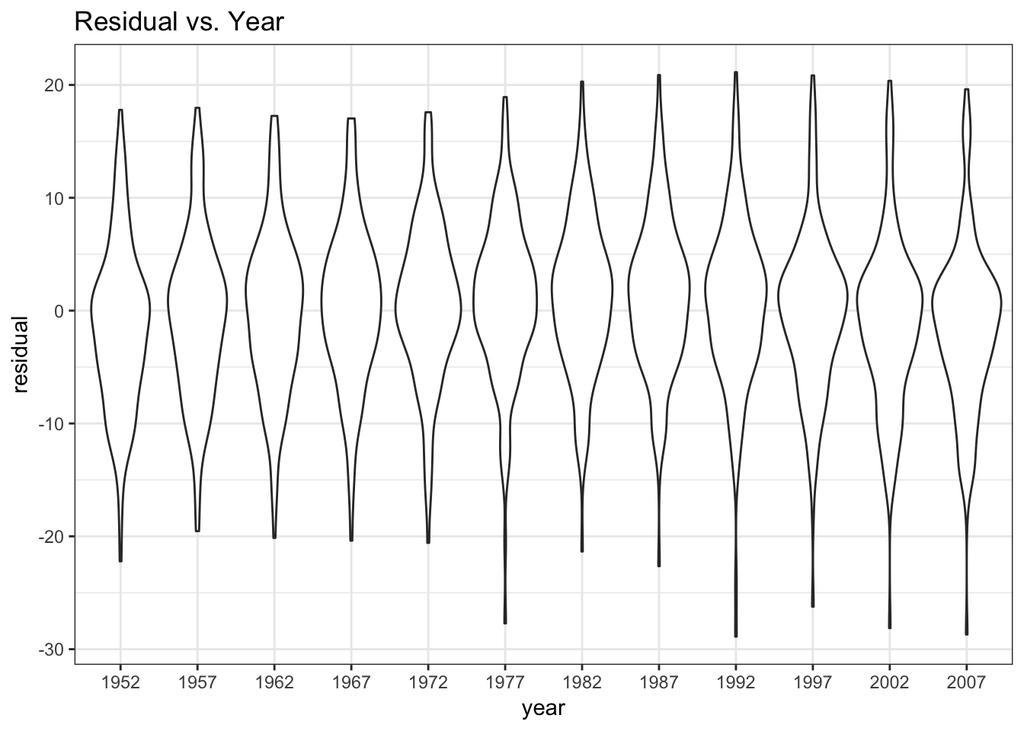

```r
multi_fit %>%
  augment(data=gapminder) %>%
  ggplot(aes(x=factor(year), y=.resid)) +
  geom_violin() +
  labs(title="Residual vs. Year",
       x = "year",
       y = "residual")
```

In the Residual vs. Fitted plot below, the residuals are not perfectly random. However, it does not show obvious bias and centered around 0. Hence, I think the performance of the interaction model is acceptable.

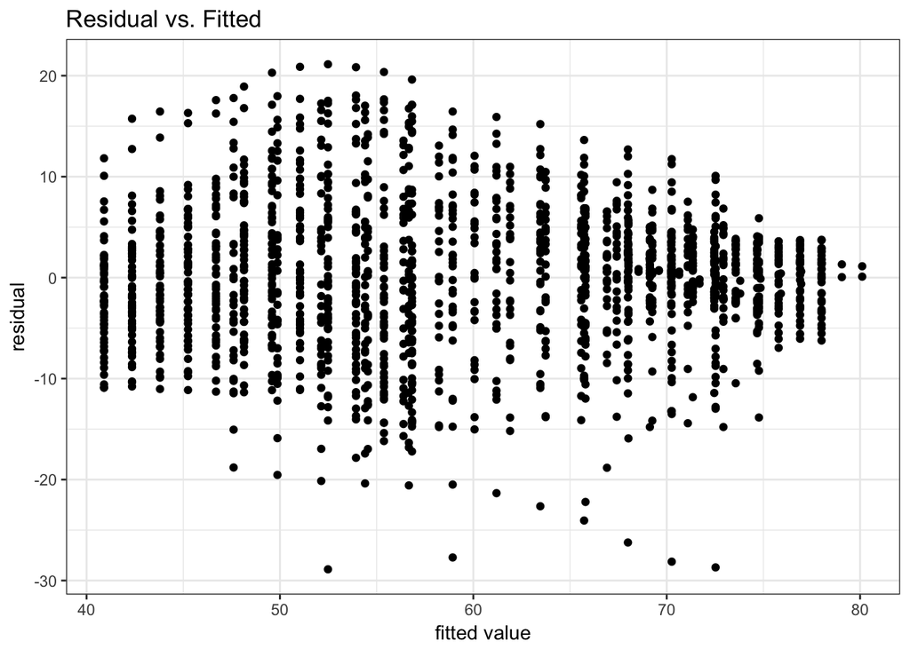

```r
multi_fit %>%
  augment(data=gapminder) %>%
  ggplot(aes(x=.fitted, y=.resid)) +
  geom_point() +
  labs(title="Residual vs. Fitted",
     x = "fitted value",
     y = "residual")
```

## Part 2: Classification

**1. Code to prepare data**

```r
library(tidyverse)
library(lubridate)
theme_set(theme_bw())

csv_file <- "Affordability_Wide_2017Q4_Public.csv"
tidy_afford <- read_csv(csv_file) %>%
  filter(Index == "Mortgage Affordability") %>%
  drop_na() %>%
  filter(RegionID != 0, RegionName != "United States") %>%
  dplyr::select(RegionID, RegionName, matches("^[1|2]")) %>%
  gather(time, affordability, matches("^[1|2]")) %>%
  type_convert(col_types=cols(time=col_date(format="%Y-%m")))
tidy_afford
```

```
## # A tibble: 12,480 x 4
##    RegionID RegionName                         time       affordability
##       <int> <chr>                              <date>             <dbl>
##  1   394913 New York, NY                       1979-03-01         0.262
##  2   753899 Los Angeles-Long Beach-Anaheim, CA 1979-03-01         0.358
##  3   394463 Chicago, IL                        1979-03-01         0.262
##  4   394514 Dallas-Fort Worth, TX              1979-03-01         0.301
##  5   394974 Philadelphia, PA                   1979-03-01         0.204
##  6   394692 Houston, TX                        1979-03-01         0.243
##  7   395209 Washington, DC                     1979-03-01         0.254
##  8   394856 Miami-Fort Lauderdale, FL          1979-03-01         0.268
##  9   394347 Atlanta, GA                        1979-03-01         0.248
## 10   394404 Boston, MA                         1979-03-01         0.222
## # ... with 12,470 more rows
```

This is what the data looks like:

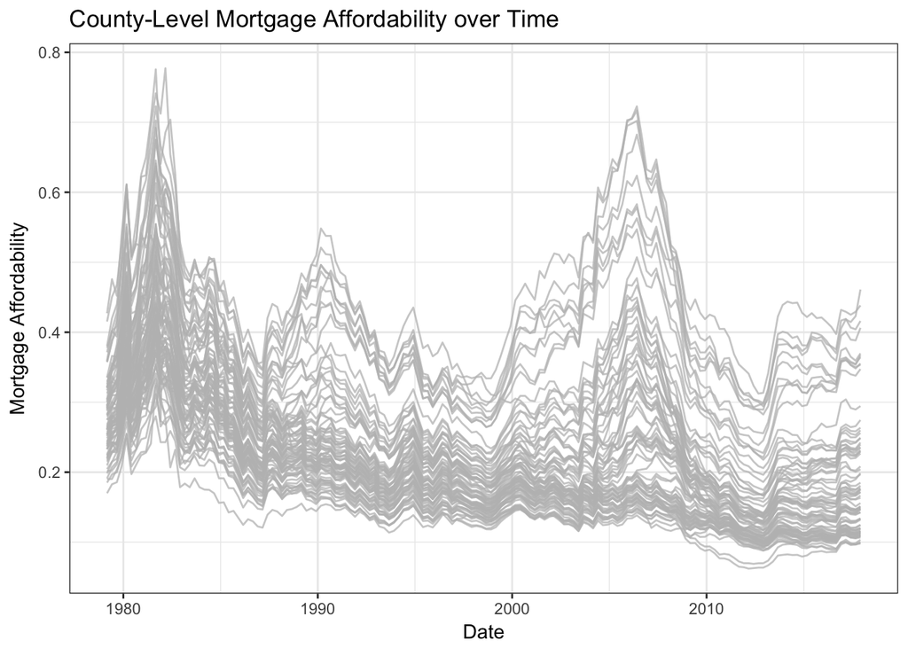

```r
tidy_afford %>%
  ggplot(aes(x=time,y=affordability,group=factor(RegionID))) +
  geom_line(color="GRAY", alpha=3/4, size=1/2) +
  labs(title="County-Level Mortgage Affordability over Time",
          x="Date", y="Mortgage Affordability")
```

Let’s create the outcome we want to predict:

```r
outcome_df <- tidy_afford %>%
  mutate(yq = quarter(time, with_year=TRUE)) %>%
  filter(yq %in% c("2016.4", "2017.4")) %>%
  select(RegionID, RegionName, yq, affordability) %>%
  spread(yq, affordability) %>%
  mutate(diff = `2017.4` - `2016.4`) %>%
  mutate(Direction = ifelse(diff>0, "up", "down")) %>%
  select(RegionID, RegionName, Direction)
outcome_df
```

```
## # A tibble: 80 x 3
##    RegionID RegionName      Direction
##       <int> <chr>           <chr>
##  1   394304 Akron, OH       down
##  2   394312 Albuquerque, NM down
##  3   394318 Allentown, PA   down
##  4   394347 Atlanta, GA     up
##  5   394355 Austin, TX      up
##  6   394357 Bakersfield, CA down
##  7   394358 Baltimore, MD   down
##  8   394367 Baton Rouge, LA up
##  9   394378 Bellingham, WA  up
## 10   394388 Birmingham, AL  down
## # ... with 70 more rows
```

For your classifiers you should use data up to 2016.

```r
predictor_df <- tidy_afford %>%
  filter(year(time) <= 2016)
predictor_df
```

```
## # A tibble: 12,160 x 4
##    RegionID RegionName                         time       affordability
##       <int> <chr>                              <date>             <dbl>
##  1   394913 New York, NY                       1979-03-01         0.262
##  2   753899 Los Angeles-Long Beach-Anaheim, CA 1979-03-01         0.358
##  3   394463 Chicago, IL                        1979-03-01         0.262
##  4   394514 Dallas-Fort Worth, TX              1979-03-01         0.301
##  5   394974 Philadelphia, PA                   1979-03-01         0.204
##  6   394692 Houston, TX                        1979-03-01         0.243
##  7   395209 Washington, DC                     1979-03-01         0.254
##  8   394856 Miami-Fort Lauderdale, FL          1979-03-01         0.268
##  9   394347 Atlanta, GA                        1979-03-01         0.248
## 10   394404 Boston, MA                         1979-03-01         0.222
## # ... with 12,150 more rows
```

**3. Code to carry out your cross-validation experiment.**

1. Prepare data for training

First, filter to the years of interest and standardize affordability for each region:

```r
standardized_df <- predictor_df %>%
  filter(year(time) %in% 2000:2016) %>%
  group_by(RegionID) %>%
  mutate(mean_aff = mean(affordability)) %>%
  mutate(sd_aff = sd(affordability)) %>%
  mutate(z_aff = (affordability - mean_aff) / sd_aff) %>%
  ungroup()
standardized_df
```

```
## # A tibble: 5,440 x 7
##    RegionID RegionName     time       affordability mean_aff sd_aff  z_aff
##       <int> <chr>          <date>             <dbl>    <dbl>  <dbl>  <dbl>
##  1   394913 New York, NY   2000-03-01         0.292    0.307 0.0612 -0.240
##  2   753899 Los Angeles-L… 2000-03-01         0.347    0.428 0.105  -0.778
##  3   394463 Chicago, IL    2000-03-01         0.221    0.191 0.0475  0.627
##  4   394514 Dallas-Fort W… 2000-03-01         0.167    0.139 0.0190  1.49
##  5   394974 Philadelphia,… 2000-03-01         0.170    0.178 0.0337 -0.252
##  6   394692 Houston, TX    2000-03-01         0.145    0.127 0.0135  1.36
##  7   395209 Washington, DC 2000-03-01         0.189    0.210 0.0478 -0.438
##  8   394856 Miami-Fort La… 2000-03-01         0.195    0.227 0.0748 -0.432
##  9   394347 Atlanta, GA    2000-03-01         0.184    0.145 0.0302  1.28
## 10   394404 Boston, MA     2000-03-01         0.275    0.268 0.0536  0.122
## # ... with 5,430 more rows
```

Second, turn the tidy dataset into a wide dataset using `tidyr::spread` then create a dataframe containing the differences we use as features:

```r
wide_df <- standardized_df %>%
  select(RegionID, time, affordability) %>%
  spread(time, affordability)
wide_df
```

```
## # A tibble: 80 x 69
##    RegionID `2000-03-01` `2000-06-01` `2000-09-01` `2000-12-01`
##  *    <int>        <dbl>        <dbl>        <dbl>        <dbl>
##  1   394304        0.188        0.191        0.184        0.175
##  2   394312        0.231        0.230        0.223        0.212
##  3   394318        0.185        0.188        0.182        0.173
##  4   394347        0.184        0.186        0.181        0.174
##  5   394355        0.175        0.181        0.179        0.172
##  6   394357        0.179        0.182        0.175        0.166
##  7   394358        0.180        0.183        0.177        0.170
##  8   394367        0.207        0.214        0.214        0.204
##  9   394378        0.270        0.274        0.266        0.246
## 10   394388        0.186        0.187        0.179        0.172
## # ... with 70 more rows, and 64 more variables: `2001-03-01` <dbl>,
## #   `2001-06-01` <dbl>, `2001-09-01` <dbl>, `2001-12-01` <dbl>,
## #   `2002-03-01` <dbl>, `2002-06-01` <dbl>, `2002-09-01` <dbl>,
## #   `2002-12-01` <dbl>, `2003-03-01` <dbl>, `2003-06-01` <dbl>,
## #   `2003-09-01` <dbl>, `2003-12-01` <dbl>, `2004-03-01` <dbl>,
## #   `2004-06-01` <dbl>, `2004-09-01` <dbl>, `2004-12-01` <dbl>,
## #   `2005-03-01` <dbl>, `2005-06-01` <dbl>, `2005-09-01` <dbl>,
## #   `2005-12-01` <dbl>, `2006-03-01` <dbl>, `2006-06-01` <dbl>,
## #   `2006-09-01` <dbl>, `2006-12-01` <dbl>, `2007-03-01` <dbl>,
## #   `2007-06-01` <dbl>, `2007-09-01` <dbl>, `2007-12-01` <dbl>,
## #   `2008-03-01` <dbl>, `2008-06-01` <dbl>, `2008-09-01` <dbl>,
## #   `2008-12-01` <dbl>, `2009-03-01` <dbl>, `2009-06-01` <dbl>,
## #   `2009-09-01` <dbl>, `2009-12-01` <dbl>, `2010-03-01` <dbl>,
## #   `2010-06-01` <dbl>, `2010-09-01` <dbl>, `2010-12-01` <dbl>,
## #   `2011-03-01` <dbl>, `2011-06-01` <dbl>, `2011-09-01` <dbl>,
## #   `2011-12-01` <dbl>, `2012-03-01` <dbl>, `2012-06-01` <dbl>,
## #   `2012-09-01` <dbl>, `2012-12-01` <dbl>, `2013-03-01` <dbl>,
## #   `2013-06-01` <dbl>, `2013-09-01` <dbl>, `2013-12-01` <dbl>,
## #   `2014-03-01` <dbl>, `2014-06-01` <dbl>, `2014-09-01` <dbl>,
## #   `2014-12-01` <dbl>, `2015-03-01` <dbl>, `2015-06-01` <dbl>,
## #   `2015-09-01` <dbl>, `2015-12-01` <dbl>, `2016-03-01` <dbl>,
## #   `2016-06-01` <dbl>, `2016-09-01` <dbl>, `2016-12-01` <dbl>
```

Third, turn this into quarterly differences:

```r
matrix_1 <- wide_df %>%
  select(-RegionID) %>%
  as.matrix() %>%
  .[,-1]

matrix_2 <- wide_df %>%
  select(-RegionID) %>%
  as.matrix() %>%
  .[,-ncol(.)]

diff_df <- (matrix_1 - matrix_2) %>%
  magrittr::set_colnames(NULL) %>%
  as_data_frame() %>%
  mutate(RegionID = wide_df$RegionID)
diff_df
```

```
## # A tibble: 80 x 68
##           V1        V2       V3       V4      V5       V6      V7       V8
##        <dbl>     <dbl>    <dbl>    <dbl>   <dbl>    <dbl>   <dbl>    <dbl>
##  1  0.00239   -6.80e⁻³ -0.00848 -5.17e⁻³ 0.00538 -0.00444 0.00743  2.74e⁻³
##  2 -0.000340  -7.94e⁻³ -0.0109  -5.72e⁻³ 0.00424 -0.00613 0.00464  5.56e⁻⁴
##  3  0.00319   -6.17e⁻³ -0.00935 -5.80e⁻³ 0.00620 -0.00336 0.00756  3.11e⁻³
##  4  0.00205   -5.03e⁻³ -0.00723 -4.04e⁻³ 0.00559 -0.00327 0.00672  2.32e⁻³
##  5  0.00557   -1.87e⁻³ -0.00659 -5.23e⁻⁴ 0.00633 -0.00605 0.00650  5.62e⁻⁴
##  6  0.00284   -7.33e⁻³ -0.00918 -4.09e⁻³ 0.00713 -0.00271 0.00792  5.11e⁻³
##  7  0.00253   -5.71e⁻³ -0.00679 -4.54e⁻³ 0.00563 -0.00251 0.00810  3.43e⁻³
##  8  0.00660   -2.34e⁻⁵ -0.00974 -2.61e⁻² 0.00478 -0.00503 0.00728 -3.31e⁻³
##  9  0.00320   -7.71e⁻³ -0.0201  -1.32e⁻² 0.00656 -0.00634 0.0162   5.81e⁻³
## 10  0.000421  -7.49e⁻³ -0.00750 -5.11e⁻³ 0.00434 -0.00363 0.00514  1.03e⁻³
## # ... with 70 more rows, and 60 more variables: V9 <dbl>, V10 <dbl>,
## #   V11 <dbl>, V12 <dbl>, V13 <dbl>, V14 <dbl>, V15 <dbl>, V16 <dbl>,
## #   V17 <dbl>, V18 <dbl>, V19 <dbl>, V20 <dbl>, V21 <dbl>, V22 <dbl>,
## #   V23 <dbl>, V24 <dbl>, V25 <dbl>, V26 <dbl>, V27 <dbl>, V28 <dbl>,
## #   V29 <dbl>, V30 <dbl>, V31 <dbl>, V32 <dbl>, V33 <dbl>, V34 <dbl>,
## #   V35 <dbl>, V36 <dbl>, V37 <dbl>, V38 <dbl>, V39 <dbl>, V40 <dbl>,
## #   V41 <dbl>, V42 <dbl>, V43 <dbl>, V44 <dbl>, V45 <dbl>, V46 <dbl>,
## #   V47 <dbl>, V48 <dbl>, V49 <dbl>, V50 <dbl>, V51 <dbl>, V52 <dbl>,
## #   V53 <dbl>, V54 <dbl>, V55 <dbl>, V56 <dbl>, V57 <dbl>, V58 <dbl>,
## #   V59 <dbl>, V60 <dbl>, V61 <dbl>, V62 <dbl>, V63 <dbl>, V64 <dbl>,
## #   V65 <dbl>, V66 <dbl>, V67 <dbl>, RegionID <int>
```

Add the outcome we want to predict from the data frame we created previously and get the data for training:

```r
final_df <- diff_df %>%
  inner_join(outcome_df %>% select(RegionID, Direction), by="RegionID") %>%
  mutate(Direction=factor(Direction, levels=c("down", "up")))
final_df
```

```
## # A tibble: 80 x 69
##           V1        V2       V3       V4      V5       V6      V7       V8
##        <dbl>     <dbl>    <dbl>    <dbl>   <dbl>    <dbl>   <dbl>    <dbl>
##  1  0.00239   -6.80e⁻³ -0.00848 -5.17e⁻³ 0.00538 -0.00444 0.00743  2.74e⁻³
##  2 -0.000340  -7.94e⁻³ -0.0109  -5.72e⁻³ 0.00424 -0.00613 0.00464  5.56e⁻⁴
##  3  0.00319   -6.17e⁻³ -0.00935 -5.80e⁻³ 0.00620 -0.00336 0.00756  3.11e⁻³
##  4  0.00205   -5.03e⁻³ -0.00723 -4.04e⁻³ 0.00559 -0.00327 0.00672  2.32e⁻³
##  5  0.00557   -1.87e⁻³ -0.00659 -5.23e⁻⁴ 0.00633 -0.00605 0.00650  5.62e⁻⁴
##  6  0.00284   -7.33e⁻³ -0.00918 -4.09e⁻³ 0.00713 -0.00271 0.00792  5.11e⁻³
##  7  0.00253   -5.71e⁻³ -0.00679 -4.54e⁻³ 0.00563 -0.00251 0.00810  3.43e⁻³
##  8  0.00660   -2.34e⁻⁵ -0.00974 -2.61e⁻² 0.00478 -0.00503 0.00728 -3.31e⁻³
##  9  0.00320   -7.71e⁻³ -0.0201  -1.32e⁻² 0.00656 -0.00634 0.0162   5.81e⁻³
## 10  0.000421  -7.49e⁻³ -0.00750 -5.11e⁻³ 0.00434 -0.00363 0.00514  1.03e⁻³
## # ... with 70 more rows, and 61 more variables: V9 <dbl>, V10 <dbl>,
## #   V11 <dbl>, V12 <dbl>, V13 <dbl>, V14 <dbl>, V15 <dbl>, V16 <dbl>,
## #   V17 <dbl>, V18 <dbl>, V19 <dbl>, V20 <dbl>, V21 <dbl>, V22 <dbl>,
## #   V23 <dbl>, V24 <dbl>, V25 <dbl>, V26 <dbl>, V27 <dbl>, V28 <dbl>,
## #   V29 <dbl>, V30 <dbl>, V31 <dbl>, V32 <dbl>, V33 <dbl>, V34 <dbl>,
## #   V35 <dbl>, V36 <dbl>, V37 <dbl>, V38 <dbl>, V39 <dbl>, V40 <dbl>,
## #   V41 <dbl>, V42 <dbl>, V43 <dbl>, V44 <dbl>, V45 <dbl>, V46 <dbl>,
## #   V47 <dbl>, V48 <dbl>, V49 <dbl>, V50 <dbl>, V51 <dbl>, V52 <dbl>,
## #   V53 <dbl>, V54 <dbl>, V55 <dbl>, V56 <dbl>, V57 <dbl>, V58 <dbl>,
## #   V59 <dbl>, V60 <dbl>, V61 <dbl>, V62 <dbl>, V63 <dbl>, V64 <dbl>,
## #   V65 <dbl>, V66 <dbl>, V67 <dbl>, RegionID <int>, Direction <fct>
```

2. Cross Vatidation Carry out 10-fold cross validation and keep track of the result for each model:

```r
library(ROCR)
library(cvTools)

fold_indices <- cvFolds(nrow(sample_frac(final_df, 1)), K=10, type = "consecutive")

cv_result <- sapply(1:10, function(fold_index) {
  test_indices <- which(fold_indices$which == fold_index)
  test_set <- final_df[test_indices,]
  train_set <- final_df[-test_indices,]

  tree_fit <- tree::tree(Direction~., data=train_set %>% select(-RegionID))
  tree_pred <- predict(tree_fit, newdata=test_set %>% select(-RegionID), type="class")
  tree_error <- mean(test_set$Direction != tree_pred)

  rf_fit <- randomForest::randomForest(Direction~., data=train_set %>% select(-RegionID))
  rf_pred <- predict(rf_fit, newdata=test_set %>% select(-RegionID))
  rf_error <- mean(test_set$Direction != rf_pred)

  tree_pred_prob <- predict(tree_fit, newdata=test_set %>% select(-RegionID), type="vector")[,2]
  rf_pred_prob <- predict(rf_fit, newdata=test_set %>% select(-RegionID), type = "prob")[,2]
  c(tree_error, rf_error, tree_pred_prob, rf_pred_prob, test_set$Direction)
})
```

Extract error rates from the cross validation result:

```r
error_rates <- cv_result[1:2,1:10]
rownames(error_rates) <- c("tree", "random forest")
error_rates <- as.data.frame(t(error_rates))
error_rates
```

```
##     tree random forest
## 1  0.500         0.500
## 2  0.500         0.625
## 3  0.125         0.500
## 4  0.625         0.500
## 5  0.125         0.375
## 6  0.000         0.125
## 7  0.500         0.250
## 8  0.375         0.250
## 9  0.500         0.250
## 10 0.125         0.625
```

Plot the error rate:

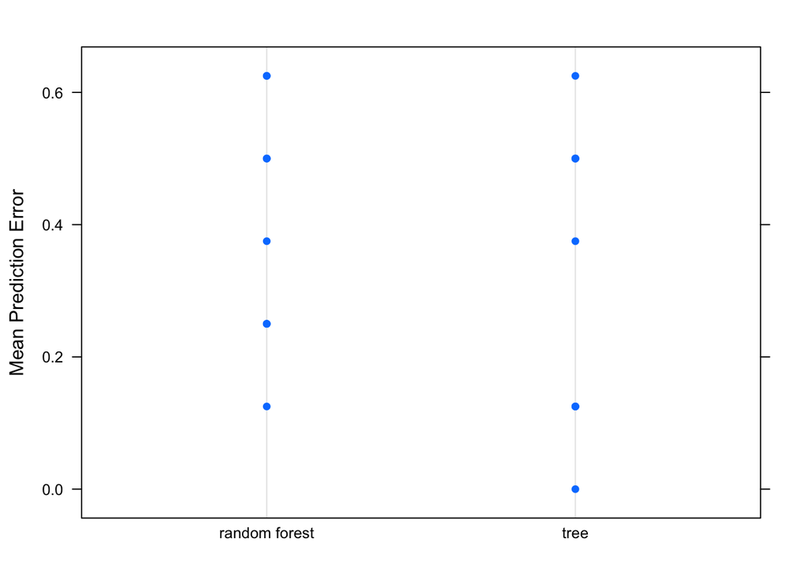

```r
error_rates <- error_rates %>%
  mutate(fold=1:n()) %>%
  gather(method,error,-fold)
dotplot(error~method, data=error_rates, ylab="Mean Prediction Error")
```

Extract data to plot AUROC curve:

```r
tree_pred <- cv_result[3:10,]
rf_pred <- cv_result[11:18,]
test_label <- cv_result[19:26,]
tree_pred <- split(tree_pred, col(tree_pred))
rf_pred <- split(rf_pred, col(rf_pred))
test_label <- split(test_label, col(test_label))
```

```r
lm(error~method, data=error_rates) %>%
  tidy()
```

```
##          term estimate  std.error  statistic      p.value
## 1 (Intercept)   0.4000 0.06298424  6.3507955 5.538661e-06
## 2  methodtree  -0.0625 0.08907316 -0.7016704 4.918583e-01
```

Draw the AUROC curve plot for Decision Tree and compute the average AUROC:

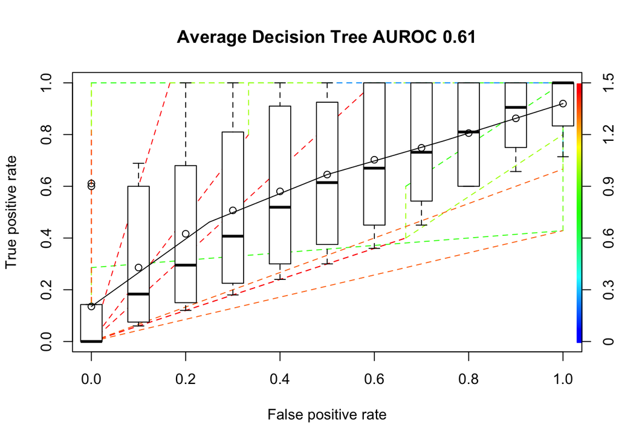

```r
pred <- prediction(tree_pred, test_label)
perf <- performance(pred,"tpr","fpr")
auc <- mean(unlist(performance(pred, "auc")@y.values))
plot(perf, colorize=T, lty=2.5, main = paste("Average Decision Tree AUROC", round(auc,2)))

plot(perf,lwd=1,avg="vertical",spread.estimate="boxplot",add=TRUE)
```

Draw the AUROC curve plot for Random Forest and compute the average AUROC:

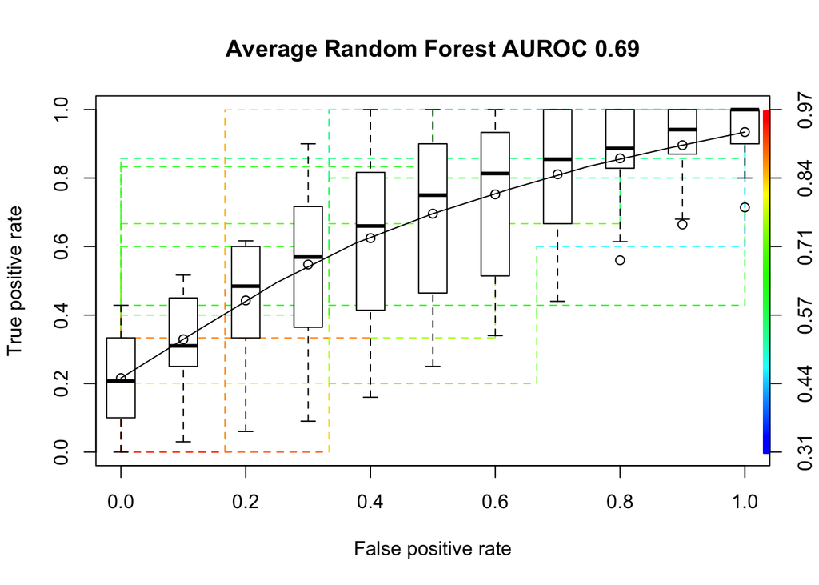

```r
pred <- prediction(rf_pred, test_label)
perf <- performance(pred,"tpr","fpr")
auc <- mean(unlist(performance(pred, "auc")@y.values))
plot(perf, colorize=T, lty=2.5, main = paste("Average Random Forest AUROC", round(auc,2)))

plot(perf,lwd=1,avg="vertical",spread.estimate="boxplot",add=TRUE)
```

**5. Interpretation and discussion of your experiment results.**  
I tend to believe that the random forest tree performs better based on the AUROC curves above because the it has a higher AUROC. However, we can not reject the null hypothesis because the p-value we got from the *t*-test is too high (>0.05). Hence in this case we do not observe significant difference between these two models.